# Empirical data analysis

Somya Mehra

2024-02-04

## Data input

```r
set.seed("260823")

source("Simulation_model_code/estimate_relatedness.R")

if (!dir.exists("Empirical_results")) dir.create("Empirical_results")

RUN_ALL <- FALSE

# WGS data for Guyana and Colombia (combined)
empirical_WGS_data <- read_rds("Empirical_data/WGS_genotype_matrix.rds")
isolate_metadata <- read_rds("Empirical_data/WGS_isolate_metadata.rds")
n_isolates <- nrow(empirical_WGS_data[["genotype_matrix"]])
n_variants <- ncol(empirical_WGS_data[["genotype_matrix"]])

RHO <- 7.4 * 10^(-7)
N_MARKER_DOWNSAMPLE <- c(100, 500, 2000, 8000)
IBD_THRESHOLDS <- seq(0.25, 0.975, 0.025)

# Simulated data (for generating composite elbow plot figure)
dense_data_sim <- read_rds("Numerical_results/Simulated_data/dense_data_simulation.rds")
dense_data_sim_ibd <- read_rds("Numerical_results/Simulated_data/dense_data_sim_ibd_estimates.rds")
GENERATION <- 10
```

## Guyana WGS data

We first analyse the set of 278 (deemed to be monoclonal) isolates sampled from Guyana.

```r
Guyana_isolates <- subset(isolate_metadata$ID, isolate_metadata$Country=="Guyana")
Guyana_genotypes <- empirical_WGS_data[["genotype_matrix"]][Guyana_isolates,]
polymorphic_SNPs <- which(colSums(Guyana_genotypes==0, na.rm=TRUE)>1 &
                            colSums(Guyana_genotypes==1, na.rm=TRUE)>1)
Guyana_genotypes <- Guyana_genotypes[, polymorphic_SNPs]
Guyana_variants <- empirical_WGS_data[["positions"]][polymorphic_SNPs,]
n_Guyana_variants <- length(polymorphic_SNPs)
```

We remove variants that are monomorphic in the Guyana to yield 16115 biallelic SNP sites. We then estimate pairwise relatedness based on these dense data for this sample.

```r
if (RUN_ALL || !file.exists("Empirical_results/Guyana_pairwise_relatedness.rds")) {
  Guyana_ibd <- generate_relatedness_summary(Guyana_genotypes, Guyana_variants, rho=RHO)
  write_rds(Guyana_ibd, "Empirical_results/Guyana_pairwise_relatedness.rds", compress="gz")
} else {
  Guyana_ibd <- read_rds("Empirical_results/Guyana_pairwise_relatedness.rds")
}
```

We also estimate pairwise relatedness for sparse data, generated by downsampling subsets of SNPs uniformly at random (without replacement).

```r
downsample_marker_subsets <- lapply(N_MARKER_DOWNSAMPLE, function(n_subset) {
  sort(sample(n_Guyana_variants, n_subset, replace=FALSE))})

names(downsample_marker_subsets) <- paste0("N_", N_MARKER_DOWNSAMPLE)

downsampled_data_ibd <- list()
for (i in names(downsample_marker_subsets)) {
  if (RUN_ALL || !file.exists(paste0("Empirical_results/Guyana_downsampled_", i, ".rds"))) {
    markers <- downsample_marker_subsets[[i]]
    downsampled_data_ibd[[i]] <- generate_relatedness_summary(Guyana_genotypes[, markers],
                                                              Guyana_variants[markers,], rho=RHO)
    write_rds(downsampled_data_ibd[[i]], paste0("Empirical_results/Guyana_downsampled_", i, ".rds"), compress="gz")
  }
  else {
    downsampled_data_ibd[[i]] <- read_rds(paste0("Empirical_results/Guyana_downsampled_", i, ".rds"))
  }
}
```

Relatedness estimates predicated on dense WGS data are treated as the gold-standard.

```r
WGS_thinned_vs_all <- lapply(downsampled_data_ibd, function(x) {
  x[["summary_metrics"]] %>%
    merge(Guyana_ibd[["summary_metrics"]], by=c("V1", "V2"),
          suffixes = c(".thinned",".all"))}) %>%
  bind_rows(.id="n_markers") %>%
  mutate(n_markers=factor(gsub("N_", "No. SNPs: ", n_markers),
                          levels=paste0("No. SNPs: ", N_MARKER_DOWNSAMPLE)))

threshold_classification <- lapply(IBD_THRESHOLDS, function(threshold) {
  classification_summary <- WGS_thinned_vs_all %>%
    mutate(thinned_class=rhat_hmm_allele.thinned>=threshold,
           WGS_class=rhat_hmm_allele.all>=threshold) %>%
    group_by(thinned_class, WGS_class, n_markers) %>%
    summarise(count=n()) %>%
    mutate(type=ifelse(thinned_class & WGS_class, "TP",
                       ifelse(thinned_class, "FP",
                              ifelse(WGS_class, "FN", "TN")))) %>%
    as.data.frame %>% select(-thinned_class, -WGS_class) %>%
    reshape2::dcast(n_markers~type, value.var="count")
  classification_summary[is.na(classification_summary)] <- 0

  cols_to_create <- setdiff(c("TN", "FN", "TP", "FP"),
                            colnames(classification_summary))
  classification_summary[cols_to_create] <- 0

  classification_summary <- classification_summary %>%
    transmute(n_markers=n_markers, threshold=threshold,
              sensitivity=TP/(TP+FN), specificity=TN/(FP+TN),
              PPV=TP/(TP+FP), NPV=TN/(FN+TN))

  return(classification_summary)}) %>%
  do.call(rbind, .) %>% as.data.frame
```

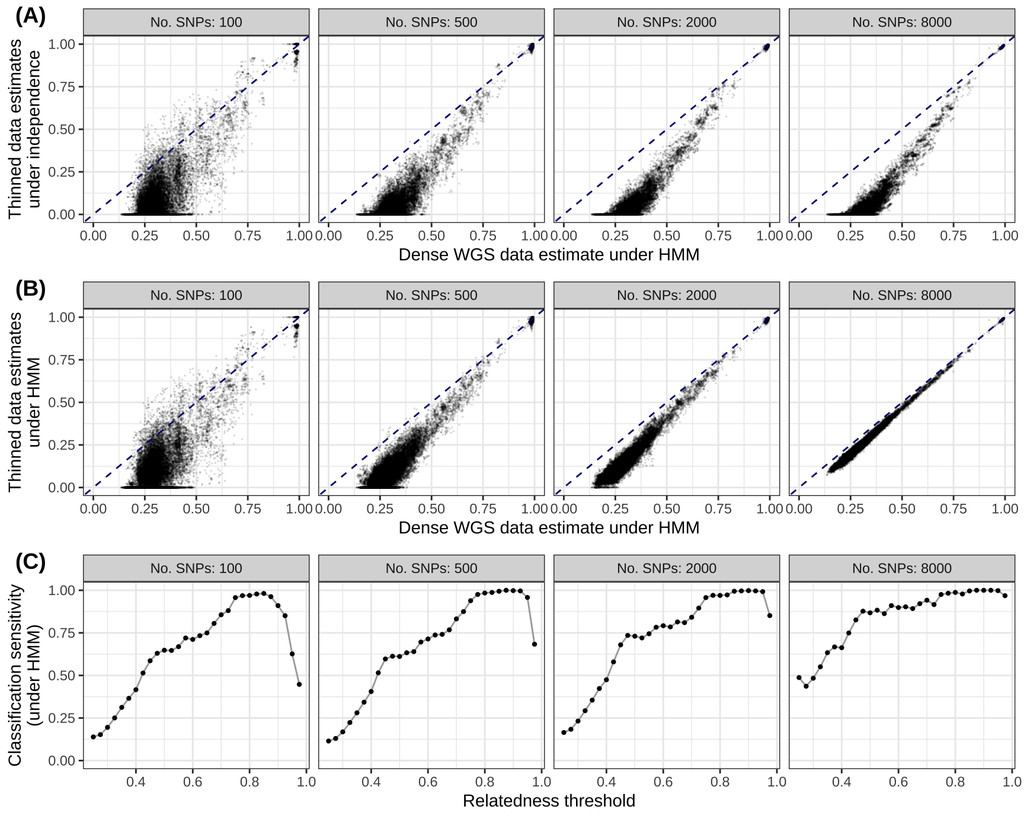

## Elbow plots

We collate the dense data diagnostic for Guyana with our theoretical and numeric results (which do not account for population structure)

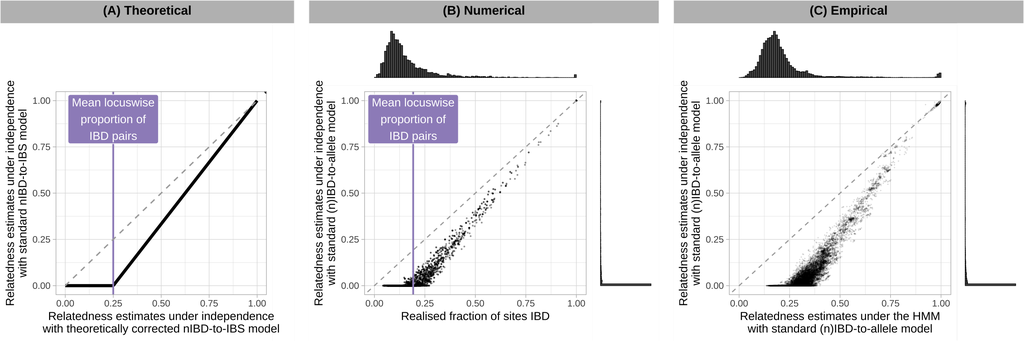

## Diagnostics for population structure

We now consider the complete sample of 306 parasites (deemed to be monoclonal) from both Guyana and Colombia, genotyped at 30694 biallelic SNP sites. We begin by generating a summary of pairwise relatedness and IBS.

```r
if (RUN_ALL || !file.exists("Empirical_results/Guyana_Colombia_pairwise_relatedness.rds")) {
  full_pop_ibd <- generate_relatedness_summary(empirical_WGS_data[["genotype_matrix"]],
                                               empirical_WGS_data[["positions"]], rho=RHO)
  write_rds(full_pop_ibd, "Empirical_results/Guyana_Colombia_pairwise_relatedness.rds",
            compress="gz")
} else {
  full_pop_ibd <- read_rds("Empirical_results/Guyana_Colombia_pairwise_relatedness.rds")
}
```

### Principal coordinates analysis

We perform principal coordinates analysis, using the proportion of nIBS sites as a distance metric and distinguish subpopulations on the basis of the first principal coordinate

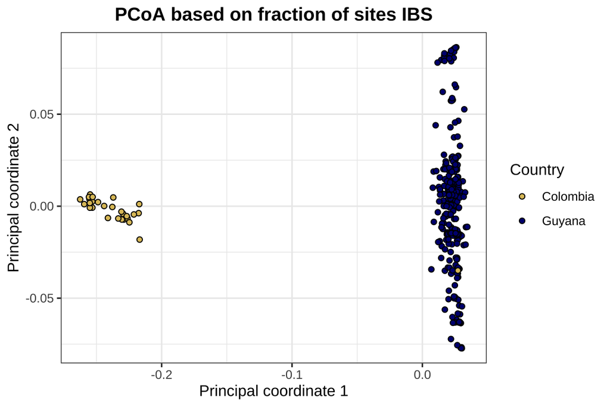

```r
n_pairs <- n_isolates*(n_isolates-1)/2
pairwise_ibs <- full_pop_ibd[["summary_metrics"]][,c("V1", "V2", "ibs")]

isolate_IDs <- rownames(empirical_WGS_data[["genotype_matrix"]])

# perform PCoA based on hamming distance
hamming_distance <- matrix(0, nrow=n_isolates, ncol=n_isolates,
                           dimnames = list(isolate_IDs, isolate_IDs))

for (i in 1:n_pairs) {
  hamming_distance[pairwise_ibs[i, "V1"], pairwise_ibs[i, "V2"]] <-
      hamming_distance[pairwise_ibs[i, "V2"], pairwise_ibs[i, "V1"]] <- 1 - pairwise_ibs[i, "ibs"]
}

hamming_pcoa <- cmdscale(hamming_distance, k=3) %>% as.data.frame %>%
  mutate(Country=isolate_metadata[rownames(.), "Country"])
```

We extract the pairwise fraction of sites IBS as diagnostic for population structure.

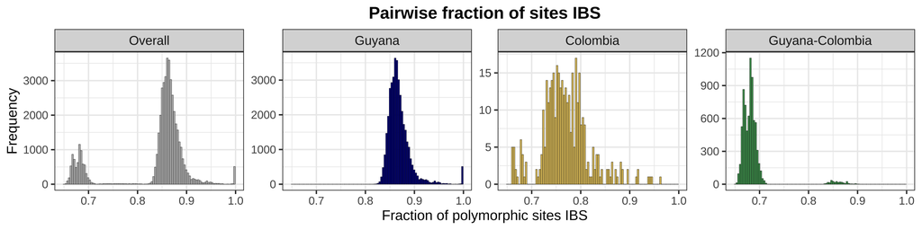

### Relatedness estimates based on allelic states vs IBS descriptives

We also compare estimates of relatedness under (n)IBD independence based on the standard (n)IBD-to-allele model vs standard nIBD-to-IBS model.

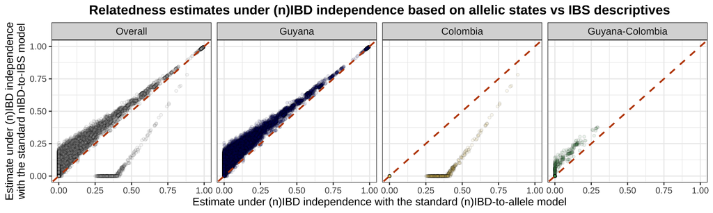

We plot the dense data diagnostic in the presence of population structure.

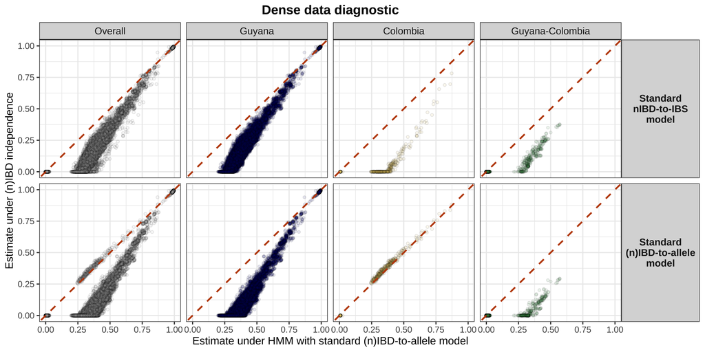

### Zero inflation

In the presence of population structure, we check for zero inflation in estimates of relatedness under (n)IBD independence based on the standard (n)IBD-to-allele model vs standard nIBD-to-IBS model.

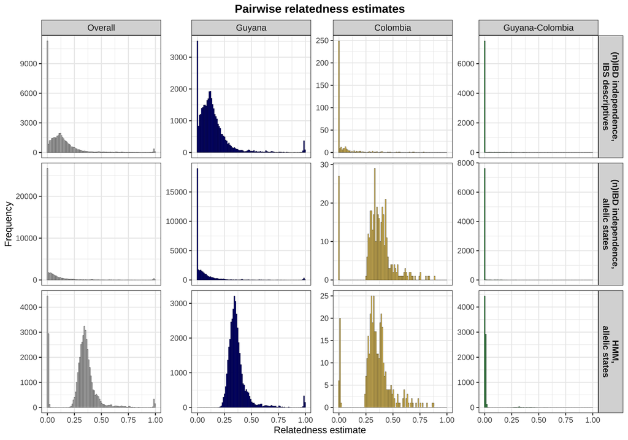